# rpca_velociraptor dynamical

Sarah Hazell Pickering

2024-08-28

Use paired end mode

```r
module="progenitors"
dataname = "rpca"
library(here); i_am(file.path("analysis",paste(module,sep="_",
                                               paste0(dataname, "_integration.Rmd"))))
```

```
## here() starts at /projects/imb-pkbphil/sp/sc_rnaseq/upr_in_adipo
```

[output not shown]

```r
indir = here("data/cellranger/count_no_introns/day0")
odir = here("output", module, dataname)
load_data = T #Loading initial seurat analysis
subset_data =  F
model="dynamical"

if (!dir.exists(odir)){dir.create(odir, recursive = T)}
```

```r
if (subset_data){
  filt = readRDS(here(odir, "10%_complete_analysis.rds"))
  Idents(filt) = "seurat_clusters"
} else {
  filt = readRDS(here(odir, "complete_analysis.rds"))
  DefaultAssay(filt) = "RNA"
}
filt
```

```
## An object of class Seurat
## 36601 features across 56638 samples within 1 assay
## Active assay: RNA (36601 features, 2000 variable features)
##  3 layers present: data, counts, scale.data
##  8 dimensional reductions calculated: pca, umap, tsne, initial.umap, initial.tsne, integrated.rpca, umap.rpca, rpca.tsne
```

```r
variable.genes = VariableFeatures(filt)
```

Equalise cell numbers between subjects with random downsampling

```r
Idents(filt) = "subject"
table(Idents(filt))
```

```
##
##    S1    S2    S3    S4    S5    S6
## 10544 13134  8290  7144 10311  7215
```

```r
#subject S4 has least number of cells after filtering
#downsample other subjects

sbs = subset(filt, downsample=sum(filt$subject =="S4"))
table(Idents(sbs))
```

```
##
##   S1   S2   S3   S4   S5   S6
## 7144 7144 7144 7144 7144 7144
```

```r
rm(filt)
Idents(sbs) = "rpca_clusters"
```

Set dataname to save a separate result for the pairedend velocity analysis

```r
red_name = "INTEGRATED.RPCA"
#umap_name = "UMAP"
clu_name =  "rpca_clusters"
#tsne_name = "TSNE"
```

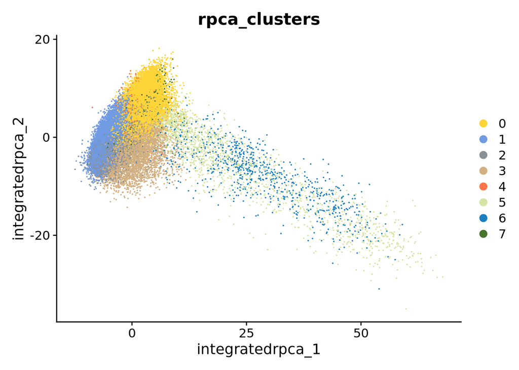

```r
DimPlot(sbs, group.by=clu_name, cols=clusters, reduction=tolower(red_name))
```

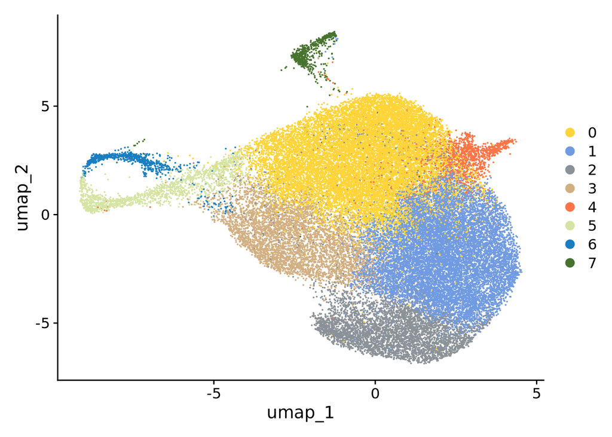

```r
DimPlot(sbs, cols=clusters, reduction="umap")
```

### Convert to SingleCell Experiment

```r
sce = as.SingleCellExperiment(sbs, assay="RNA")
```

[output not shown]

[output cut: 27 more lines]

[output not shown]

```r
sce
```

```
## class: SingleCellExperiment
## dim: 36601 42864
## metadata(0):
## assays(3): counts logcounts scaledata
## rownames(36601): MIR1302-2HG FAM138A ... AC007325.4 AC007325.2
## rowData names(0):
## colnames(42864): day0.subjectS1_AAACCTGAGCTGTCTA-1
##   day0.subjectS1_AAACCTGAGTACGACG-1 ...
##   day0.subjectS6_TTTGTCATCACGGTTA-1 day0.subjectS6_TTTGTCATCCGCTGTT-1
## colData names(10): orig.ident nCount_RNA ... rpca_clusters ident
## reducedDimNames(8): PCA UMAP ... UMAP.RPCA RPCA.TSNE
## mainExpName: RNA
## altExpNames(0):
```

```r
rowData(sce)
```

```
## DataFrame with 36601 rows and 0 columns
```

```r
head(rownames(sce))
```

```
## [1] "MIR1302-2HG" "FAM138A"     "OR4F5"       "AL627309.1"  "AL627309.3"
## [6] "AL627309.2"
```

```r
head(colData(sce))
```

```
## DataFrame with 6 rows and 10 columns
##                                    orig.ident nCount_RNA nFeature_RNA
##                                   <character>  <numeric>    <numeric>
## day0.subjectS1_AAACCTGAGCTGTCTA-1          S1      15710         3897
## day0.subjectS1_AAACCTGAGTACGACG-1          S1      18328         4488
## day0.subjectS1_AAACCTGCAAACTGCT-1          S1      23579         4820
## day0.subjectS1_AAACCTGCAAGGCTCC-1          S1      15057         3796
## day0.subjectS1_AAACCTGCACAAGTAA-1          S1      17696         3907
## day0.subjectS1_AAACCTGCATCTCGCT-1          S1      67345         7212
##                                       subject percent.mt RNA_snn_res.0.5
##                                   <character>  <numeric>        <factor>
## day0.subjectS1_AAACCTGAGCTGTCTA-1          S1   1.094844               0
## day0.subjectS1_AAACCTGAGTACGACG-1          S1   0.141859               0
## day0.subjectS1_AAACCTGCAAACTGCT-1          S1   0.500445               0
## day0.subjectS1_AAACCTGCAAGGCTCC-1          S1   0.883310               0
## day0.subjectS1_AAACCTGCACAAGTAA-1          S1   0.943716               0
## day0.subjectS1_AAACCTGCATCTCGCT-1          S1   0.467741               0
##                                   seurat_clusters initial_clusters
##                                          <factor>         <factor>
## day0.subjectS1_AAACCTGAGCTGTCTA-1               1                0
## day0.subjectS1_AAACCTGAGTACGACG-1               1                0
## day0.subjectS1_AAACCTGCAAACTGCT-1               1                0
## day0.subjectS1_AAACCTGCAAGGCTCC-1               2                0
## day0.subjectS1_AAACCTGCACAAGTAA-1               2                0
## day0.subjectS1_AAACCTGCATCTCGCT-1               0                0
##                                   rpca_clusters    ident
##                                        <factor> <factor>
## day0.subjectS1_AAACCTGAGCTGTCTA-1             1        1
## day0.subjectS1_AAACCTGAGTACGACG-1             1        1
## day0.subjectS1_AAACCTGCAAACTGCT-1             1        1
## day0.subjectS1_AAACCTGCAAGGCTCC-1             2        2
## day0.subjectS1_AAACCTGCACAAGTAA-1             2        2
## day0.subjectS1_AAACCTGCATCTCGCT-1             0        0
```

```r
rm(sbs)
```

## Load our unspliced data

```r
samples = list.dirs(here(indir), full.names = F, recursive = F)
samples = samples[grep("p.chr18|beige", samples, invert = T)]

data_list = c()
for (i in 1:length(samples)){
  print(samples[i])
  #Finding file name if different from sample/dir name
  path = here(indir, samples[i], "velocyto")
  fn = list.files(path)
  fn = fn[grep("Sample.\\.loom", fn)]

  loom = import(here(path, fn),
                type="SingleCellLoomExperiment")
  cell_id = paste0(gsub("_",".",samples[i]),"_")
  colnames(loom) = gsub(".*:",cell_id, gsub("x$","-1",colData(loom)$CellID))
  rownames(loom) = rowData(loom)$Gene
  rownames(loom)[duplicated(rownames(loom))] = paste0(rownames(loom)[duplicated(rownames(loom))], ".1")
  data_list = c(data_list,loom)
}
```

```
## [1] "day0_subjectS1"
## [1] "day0_subjectS2"
## [1] "day0_subjectS3"
## [1] "day0_subjectS4"
## [1] "day0_subjectS5"
## [1] "day0_subjectS6"
```

```r
summary(data_list)
```

```
##      Length Class                    Mode
## [1,] 36601  SingleCellLoomExperiment S4
## [2,] 36601  SingleCellLoomExperiment S4
## [3,] 36601  SingleCellLoomExperiment S4
## [4,] 36601  SingleCellLoomExperiment S4
## [5,] 36601  SingleCellLoomExperiment S4
## [6,] 36601  SingleCellLoomExperiment S4
```

```r
loom = do.call(cbind, data_list)
loom
```

```
## class: SingleCellLoomExperiment
## dim: 36601 59720
## metadata(30): last_modified CreationDate ... velocyto.__version__
##   velocyto.logic
## assays(4): matrix ambiguous spliced unspliced
## rownames(36601): BX004987.1 AC145212.1 ... CDY1 TTTY3
## rowData names(6): Accession Chromosome ... Start Strand
## colnames(59720): day0.subjectS1_AAACCTGGTTAGATGA-1
##   day0.subjectS1_AAAGATGGTCTGCAAT-1 ...
##   day0.subjectS6_TTTCCTCCAGACACTT-1 day0.subjectS6_TTTGCGCTCTGCTGCT-1
## colData names(1): CellID
## reducedDimNames(0):
## mainExpName: NULL
## altExpNames(0):
## rowGraphs(0): NULL
## colGraphs(0): NULL
```

```r
rowData(loom)
```

```
## DataFrame with 36601 rows and 6 columns
##                  Accession  Chromosome       End        Gene     Start
##                <character> <character> <integer> <character> <integer>
## BX004987.1 ENSG00000278704  GL000009.2     58376  BX004987.1     56140
## AC145212.1 ENSG00000277400  GL000194.1    115018  AC145212.1     53590
## MAFIP      ENSG00000274847  GL000194.1    115055       MAFIP     53594
## AC011043.1 ENSG00000276256  GL000195.1     49164  AC011043.1     42939
## AC011043.2 ENSG00000278198  GL000195.1    179372  AC011043.2    173872
## ...                    ...         ...       ...         ...       ...
## TTTY4B     ENSG00000235412           Y  24607025      TTTY4B  24570202
## BPY2B      ENSG00000183795           Y  24639207       BPY2B  24607560
## DAZ4       ENSG00000205916           Y  24907040        DAZ4  24833843
## CDY1       ENSG00000172288           Y  25624902        CDY1  25622162
## TTTY3      ENSG00000231141           Y  25733388       TTTY3  25728490
##                 Strand
##            <character>
## BX004987.1           -
## AC145212.1           -
## MAFIP                -
## AC011043.1           -
## AC011043.2           +
## ...                ...
## TTTY4B               +
## BPY2B                +
## DAZ4                 +
## CDY1                 +
## TTTY3                +
```

```r
colData(loom)
```

```
## DataFrame with 59720 rows and 1 column
##                                                   CellID
##                                              <character>
## day0.subjectS1_AAACCTGGTTAGATGA-1 Sample4:AAACCTGGTTAG..
## day0.subjectS1_AAAGATGGTCTGCAAT-1 Sample4:AAAGATGGTCTG..
## day0.subjectS1_AAAGTAGAGTAGTGCG-1 Sample4:AAAGTAGAGTAG..
## day0.subjectS1_AAACCTGTCACCTTAT-1 Sample4:AAACCTGTCACC..
## day0.subjectS1_AAACCTGAGACTAGAT-1 Sample4:AAACCTGAGACT..
## ...                                                  ...
## day0.subjectS6_TTTCCTCTCTTGTCAT-1 Sample5:TTTCCTCTCTTG..
## day0.subjectS6_TTTGCGCGTATAGTAG-1 Sample5:TTTGCGCGTATA..
## day0.subjectS6_TTTCCTCCACTATCTT-1 Sample5:TTTCCTCCACTA..
## day0.subjectS6_TTTCCTCCAGACACTT-1 Sample5:TTTCCTCCAGAC..
## day0.subjectS6_TTTGCGCTCTGCTGCT-1 Sample5:TTTGCGCTCTGC..
```

```r
assays(loom)[["unspliced"]]
```

```
## <36601 x 59720> matrix of class DelayedMatrix and type "integer":
##            day0.subjectS1_AAACCTGGTTAGATGA-1 ...
## BX004987.1                                 0   .
## AC145212.1                                 0   .
##      MAFIP                                 0   .
## AC011043.1                                 0   .
## AC011043.2                                 0   .
##        ...                                 .   .
##     TTTY4B                                 0   .
##      BPY2B                                 0   .
##       DAZ4                                 0   .
##       CDY1                                 0   .
##      TTTY3                                 0   .
##            day0.subjectS6_TTTGCGCTCTGCTGCT-1
## BX004987.1                                 0
## AC145212.1                                 0
##      MAFIP                                 0
## AC011043.1                                 0
## AC011043.2                                 0
##        ...                                 .
##     TTTY4B                                 0
##      BPY2B                                 0
##       DAZ4                                 0
##       CDY1                                 0
##      TTTY3                                 0
```

```r
loom$subject = gsub("_.*","", gsub("day0\\.subject", "",colnames(loom)))
table(loom$subject)
```

```
##
##    S1    S2    S3    S4    S5    S6
## 10829 13937  8812  8033 10556  7553
```

### Combine objects

the handling of duplicate gene names is different between the two methods. The loom stores more gene information, so it doesn’t matter about the duplicates. seurat though doesn’t load the extra gene information

```r
summary(rownames(sce) %in% rownames(loom))
```

```
##    Mode    TRUE
## logical   36601
```

```r
summary(colnames(sce) %in% colnames(loom))
```

```
##    Mode    TRUE
## logical   42864
```

```r
head(colnames(sce)[!colnames(sce) %in% colnames(loom)] )
```

```
## character(0)
```

```r
# one cell missing because cellranger filtering
ncol(sce)
```

```
## [1] 42864
```

```r
sce = sce[,colnames(sce) %in% colnames(loom)]
ncol(sce)
```

```
## [1] 42864
```

```r
# filter cells from seurat analysis
filt = loom[rownames(sce),colnames(sce)]

assays(sce)[["unspliced"]] = assays(filt)[["unspliced"]]
assays(sce)[["spliced"]] = assays(filt)[["spliced"]]
sce
```

```
## class: SingleCellExperiment
## dim: 36601 42864
## metadata(0):
## assays(5): counts logcounts scaledata unspliced spliced
## rownames(36601): MIR1302-2HG FAM138A ... AC007325.4 AC007325.2
## rowData names(0):
## colnames(42864): day0.subjectS1_AAACCTGAGCTGTCTA-1
##   day0.subjectS1_AAACCTGAGTACGACG-1 ...
##   day0.subjectS6_TTTGTCATCACGGTTA-1 day0.subjectS6_TTTGTCATCCGCTGTT-1
## colData names(10): orig.ident nCount_RNA ... rpca_clusters ident
## reducedDimNames(8): PCA UMAP ... UMAP.RPCA RPCA.TSNE
## mainExpName: RNA
## altExpNames(0):
```

```r
table(sce$subject)
```

```
##
##   S1   S2   S3   S4   S5   S6
## 7144 7144 7144 7144 7144 7144
```

## Get some stats on the unspliced counts

Sum = total counts and detected = the number of detected features calculating for the unspliced

```r
sce <- addPerCellQC(sce,
    subsets=list(Mito=grep("MT-", rownames(sce))),
    assay.type = "unspliced")
colData(sce)
```

```
## DataFrame with 42864 rows and 16 columns
##                                    orig.ident nCount_RNA nFeature_RNA
##                                   <character>  <numeric>    <numeric>
## day0.subjectS1_AAACCTGAGCTGTCTA-1          S1      15710         3897
## day0.subjectS1_AAACCTGAGTACGACG-1          S1      18328         4488
## day0.subjectS1_AAACCTGCAAACTGCT-1          S1      23579         4820
## day0.subjectS1_AAACCTGCAAGGCTCC-1          S1      15057         3796
## day0.subjectS1_AAACCTGCACAAGTAA-1          S1      17696         3907
## ...                                       ...        ...          ...
## day0.subjectS6_TTTGTCAAGTACGTAA-1          S6      40019         5799
## day0.subjectS6_TTTGTCAAGTAGGCCA-1          S6      67547         7814
## day0.subjectS6_TTTGTCACACGGCCAT-1          S6      26131         4772
## day0.subjectS6_TTTGTCATCACGGTTA-1          S6      29644         5465
## day0.subjectS6_TTTGTCATCCGCTGTT-1          S6      50592         6495
##                                       subject percent.mt RNA_snn_res.0.5
##                                   <character>  <numeric>        <factor>
## day0.subjectS1_AAACCTGAGCTGTCTA-1          S1   1.094844               0
## day0.subjectS1_AAACCTGAGTACGACG-1          S1   0.141859               0
## day0.subjectS1_AAACCTGCAAACTGCT-1          S1   0.500445               0
## day0.subjectS1_AAACCTGCAAGGCTCC-1          S1   0.883310               0
## day0.subjectS1_AAACCTGCACAAGTAA-1          S1   0.943716               0
## ...                                       ...        ...             ...
## day0.subjectS6_TTTGTCAAGTACGTAA-1          S6   0.192409               0
## day0.subjectS6_TTTGTCAAGTAGGCCA-1          S6   0.461901               4
## day0.subjectS6_TTTGTCACACGGCCAT-1          S6   0.765374               0
## day0.subjectS6_TTTGTCATCACGGTTA-1          S6   0.512751               1
## day0.subjectS6_TTTGTCATCCGCTGTT-1          S6   0.110689               4
##                                   seurat_clusters initial_clusters
##                                          <factor>         <factor>
## day0.subjectS1_AAACCTGAGCTGTCTA-1               1                0
## day0.subjectS1_AAACCTGAGTACGACG-1               1                0
## day0.subjectS1_AAACCTGCAAACTGCT-1               1                0
## day0.subjectS1_AAACCTGCAAGGCTCC-1               2                0
## day0.subjectS1_AAACCTGCACAAGTAA-1               2                0
## ...                                           ...              ...
## day0.subjectS6_TTTGTCAAGTACGTAA-1               2                0
## day0.subjectS6_TTTGTCAAGTAGGCCA-1               5                4
## day0.subjectS6_TTTGTCACACGGCCAT-1               3                0
## day0.subjectS6_TTTGTCATCACGGTTA-1               3                1
## day0.subjectS6_TTTGTCATCCGCTGTT-1               0                4
```

[output cut: 24 more lines]

```
## day0.subjectS6_TTTGTCATCACGGTTA-1                0                     0
## day0.subjectS6_TTTGTCATCCGCTGTT-1                0                     0
##                                   subsets_Mito_percent     total
##                                              <numeric> <numeric>
## day0.subjectS1_AAACCTGAGCTGTCTA-1                    0      1981
## day0.subjectS1_AAACCTGAGTACGACG-1                    0      2428
## day0.subjectS1_AAACCTGCAAACTGCT-1                    0      3176
## day0.subjectS1_AAACCTGCAAGGCTCC-1                    0      2163
## day0.subjectS1_AAACCTGCACAAGTAA-1                    0      2028
## ...                                                ...       ...
## day0.subjectS6_TTTGTCAAGTACGTAA-1                    0      6404
## day0.subjectS6_TTTGTCAAGTAGGCCA-1                    0      8888
## day0.subjectS6_TTTGTCACACGGCCAT-1                    0      3220
## day0.subjectS6_TTTGTCATCACGGTTA-1                    0      3841
## day0.subjectS6_TTTGTCATCCGCTGTT-1                    0      6126
```

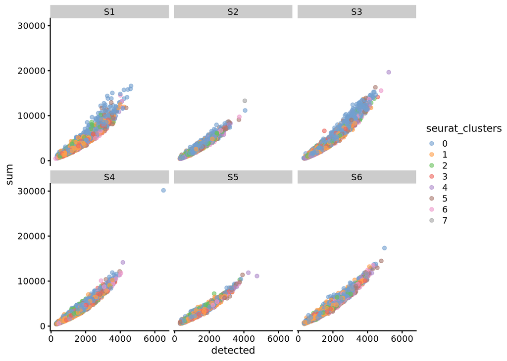

```r
plotColData(sce, y = "sum", x="detected", color_by="seurat_clusters", other_fields = "subject") + facet_wrap(~subject)
```

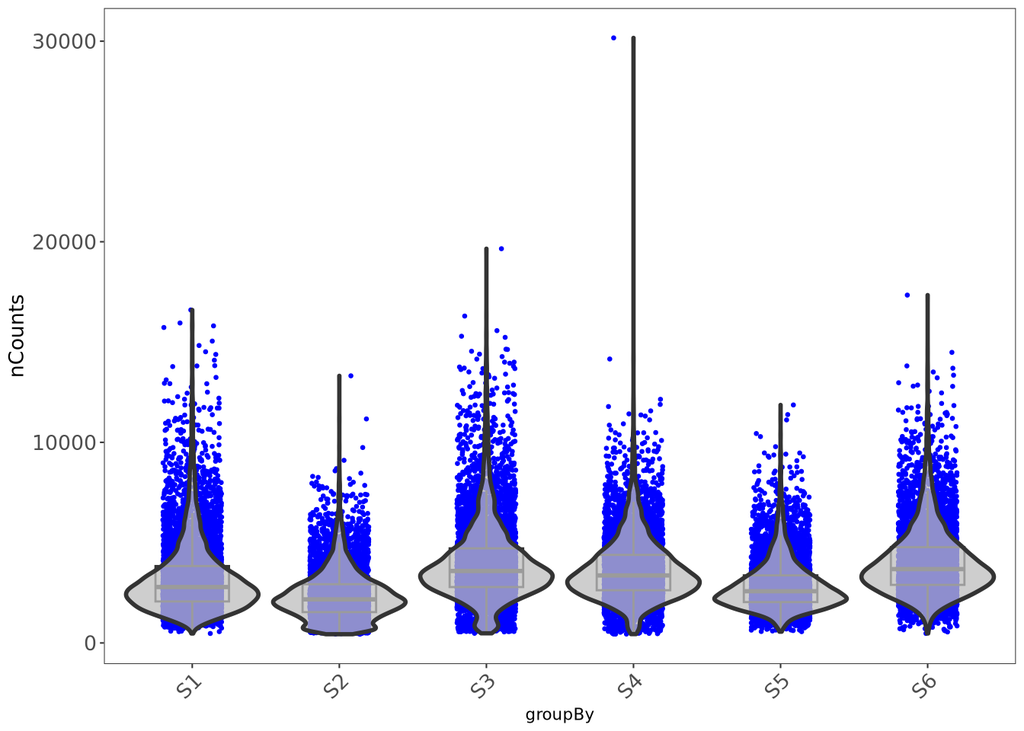

```r
singleCellTK::plotSCEViolin(sce, "colData", "sum", groupBy = "subject", ylab="nCounts")
```

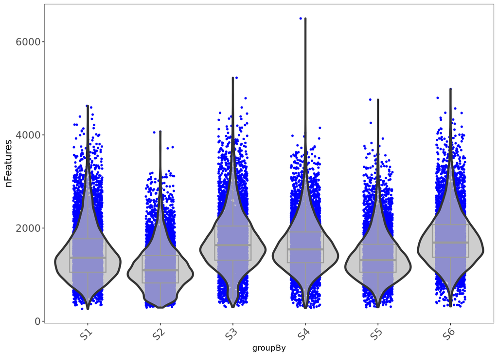

```r
singleCellTK::plotSCEViolin(sce, "colData", "detected", groupBy = "subject", ylab ="nFeatures")
```

## Filter low expr genes

```r
nonzeroes = (assay(sce, "spliced") > 0 )* (assay(sce, "unspliced") > 0)
head(nonzeroes)
```

```
## <6 x 42864> matrix of class DelayedMatrix and type "integer":
##             day0.subjectS1_AAACCTGAGCTGTCTA-1 ...
## MIR1302-2HG                                 0   .
## FAM138A                                     0   .
## OR4F5                                       0   .
## AL627309.1                                  0   .
## AL627309.3                                  0   .
## AL627309.2                                  0   .
##             day0.subjectS6_TTTGTCATCCGCTGTT-1
## MIR1302-2HG                                 0
## FAM138A                                     0
## OR4F5                                       0
## AL627309.1                                  0
## AL627309.3                                  0
## AL627309.2                                  0
```

```r
shared_counts = assay(sce, "spliced")*nonzeroes + assay(sce, "unspliced")*nonzeroes
head(shared_counts)
```

```
## <6 x 42864> matrix of class DelayedMatrix and type "integer":
##             day0.subjectS1_AAACCTGAGCTGTCTA-1 ...
## MIR1302-2HG                                 0   .
## FAM138A                                     0   .
## OR4F5                                       0   .
## AL627309.1                                  0   .
## AL627309.3                                  0   .
## AL627309.2                                  0   .
##             day0.subjectS6_TTTGTCATCCGCTGTT-1
## MIR1302-2HG                                 0
## FAM138A                                     0
## OR4F5                                       0
## AL627309.1                                  0
## AL627309.3                                  0
## AL627309.2                                  0
```

```r
genes_to_keep = rowSums(shared_counts) > 20
summary(genes_to_keep)
```

```
##    Mode   FALSE    TRUE
## logical   24097   12504
```

```r
filt = sce[genes_to_keep,]
filt
```

```
## class: SingleCellExperiment
## dim: 12504 42864
## metadata(0):
## assays(5): counts logcounts scaledata unspliced spliced
## rownames(12504): LINC01409 LINC01128 ... AL592183.1 AC240274.1
## rowData names(0):
## colnames(42864): day0.subjectS1_AAACCTGAGCTGTCTA-1
##   day0.subjectS1_AAACCTGAGTACGACG-1 ...
##   day0.subjectS6_TTTGTCATCACGGTTA-1 day0.subjectS6_TTTGTCATCCGCTGTT-1
## colData names(16): orig.ident nCount_RNA ... subsets_Mito_percent total
## reducedDimNames(8): PCA UMAP ... UMAP.RPCA RPCA.TSNE
## mainExpName: RNA
## altExpNames(0):
```

```r
summary(variable.genes %in% rownames(filt))
```

```
##    Mode   FALSE    TRUE
## logical     553    1447
```

```r
variable.genes = variable.genes[variable.genes %in% rownames(filt)]
reducedDimNames(sce)
```

```
## [1] "PCA"             "UMAP"            "TSNE"            "INITIAL.UMAP"
## [5] "INITIAL.TSNE"    "INTEGRATED.RPCA" "UMAP.RPCA"       "RPCA.TSNE"
```

## Starting velocity analysis

Supplying variable genes and previously computed Integration reduction (acts as a PCA)

```r
velo.out = scvelo(sce, subset.row = variable.genes, use.dimred=red_name,
                  assay.X="counts", mode= model)
```

```
## computing neighbors
##     finished (0:00:41) --> added
##     'distances' and 'connectivities', weighted adjacency matrices (adata.obsp)
## computing moments based on connectivities
##     finished (0:00:16) --> added
##     'Ms' and 'Mu', moments of un/spliced abundances (adata.layers)
## recovering dynamics
## ... 0%... 0%... 0%... 0%... 0%... 0%... 0%... 0%... 0%... 1%... 1%... 1%... 1%... 1%... 1%... 1%... 1%... 1%... 1%... 2%... 2%... 2%... 2%... 2%... 2%... 2%... 2%... 2%... 3%... 3%... 3%... 3%... 3%... 3%... 3%... 3%... 3%... 4%... 4%... 4%... 4%... 4%... 4%... 4%... 4%... 4%... 5%... 5%... 5%...…
##     'fit_pars', fitted parameters for splicing dynamics (adata.var)
## computing velocities
##     finished (0:00:43) --> added
##     'velocity', velocity vectors for each individual cell (adata.layers)
## computing velocity graph
## ... 1%... 3%... 5%... 7%... 9%... 11%... 13%... 15%... 17%... 19%... 20%... 22%... 24%... 26%... 28%... 30%... 32%... 34%... 36%... 38%... 40%... 42%... 44%... 45%... 47%... 49%... 51%... 53%... 55%... 57%... 59%... 61%... 63%... 65%... 67%... 69%... 71%... 73%... 75%... 77%... 79%... 81%... 83%.…
##     'velocity_graph', sparse matrix with cosine correlations (adata.uns)
## computing terminal states
##     identified 9 regions of root cells and 1 region of end points .
##     finished (0:00:56) --> added
##     'root_cells', root cells of Markov diffusion process (adata.obs)
##     'end_points', end points of Markov diffusion process (adata.obs)
## computing latent time using root_cells as prior
##     finished (0:00:22) --> added
##     'latent_time', shared time (adata.obs)
## --> added 'velocity_length' (adata.obs)
## --> added 'velocity_confidence' (adata.obs)
## --> added 'velocity_confidence_transition' (adata.obs)
```

```r
velo.out
```

```
## class: SingleCellExperiment
## dim: 1447 42864
## metadata(5): neighbors recover_dynamics velocity_params velocity_graph
##   velocity_graph_neg
## assays(10): X spliced ... velocity velocity_u
## rownames(1447): SFRP2 TRH ... GINS1 LIN7A
## rowData names(18): fit_r2 fit_alpha ... velocity_genes varm
## colnames(42864): day0.subjectS1_AAACCTGAGCTGTCTA-1
##   day0.subjectS1_AAACCTGAGTACGACG-1 ...
##   day0.subjectS6_TTTGTCATCACGGTTA-1 day0.subjectS6_TTTGTCATCCGCTGTT-1
## colData names(8): velocity_self_transition root_cells ...
##   velocity_confidence velocity_confidence_transition
## reducedDimNames(1): X_pca
## mainExpName: NULL
## altExpNames(0):
```

```r
sce$velocity_pseudotime = velo.out$velocity_pseudotime
```

## pseuodtime

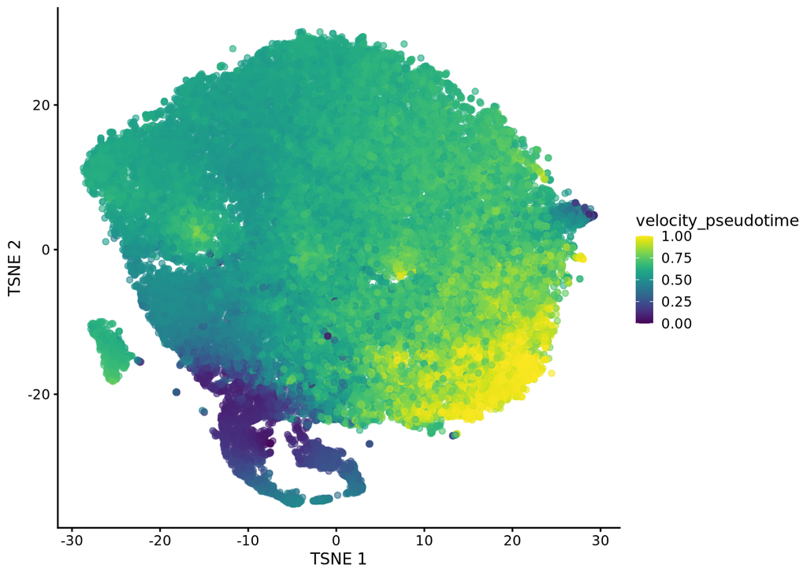

```r
plotTSNE(sce, color_by="velocity_pseudotime")
```

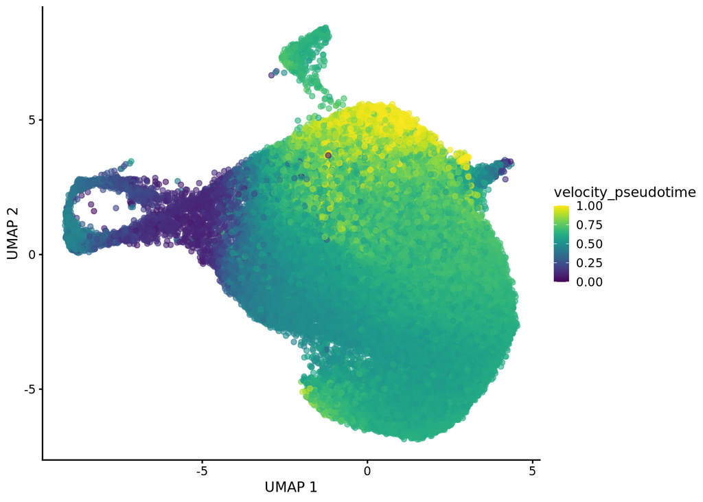

```r
plotUMAP(sce, color_by="velocity_pseudotime")
```

## Arrows on PCA

```r
embedded_pca <- embedVelocity(reducedDim(sce, red_name), velo.out)
```

```
## ℹ Using the 'X' assay as the X matrix
```

```
## computing velocity embedding
##     finished (0:00:27) --> added
##     'velocity_target', embedded velocity vectors (adata.obsm)
```

```r
dim(embedded_pca)
```

```
## [1] 42864    50
```

```r
reducedDim(sce, "PCA.SIMPLE") = reducedDim(sce, red_name)[,1:2]
grid.df <- gridVectors(sce, embedded_pca[,1:2], use.dimred = "PCA.SIMPLE")
colnames(grid.df) = gsub(gsub("\\.","",red_name), "PC", colnames(grid.df), ignore.case = T)
head(grid.df)
```

```
##   start.PC_1 start.PC_2   end.PC_1   end.PC_2
## 1 -3.3417183   2.830272 -2.4307653  4.1329773
## 2 -1.3463761   4.197275 -0.2855991  5.5590210
## 4 -3.4823790  -1.087762 -2.7162639 -0.9661307
## 5 -1.4329402   2.878414 -0.3307836  4.1227942
## 6  0.5688267   4.244724  1.4525574  5.2247081
## 7  4.4440868   9.498588  4.2051289  9.7042529
```

```r
dim(grid.df)
```

```
## [1] 540   4
```

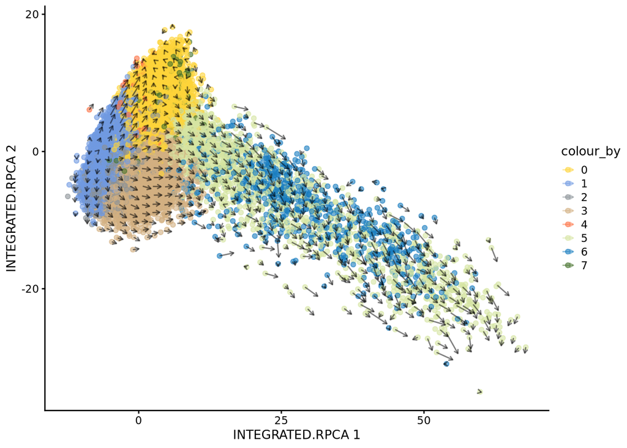

```r
plotReducedDim(sce, red_name,colour_by=clu_name) +
    geom_segment(data=grid.df, mapping=aes(x=start.PC_1, y=start.PC_2,
        xend=end.PC_1, yend=end.PC_2, colour=NULL), alpha=0.5,arrow=arrow(length=unit(0.05, "inches"))) &
  scale_colour_manual(values=clusters)
```

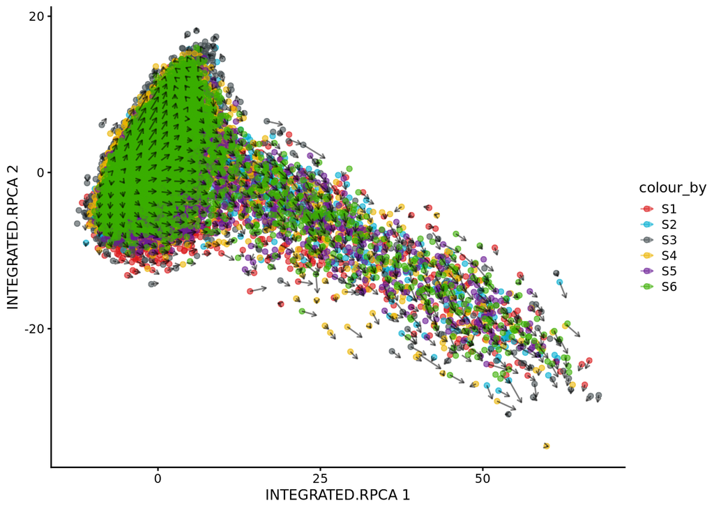

```r
plotReducedDim(sce, red_name,colour_by="subject") +
    geom_segment(data=grid.df, mapping=aes(x=start.PC_1, y=start.PC_2,
        xend=end.PC_1, yend=end.PC_2, colour=NULL), alpha=0.5,arrow=arrow(length=unit(0.05, "inches"))) &
  scale_colour_manual(values=pal)
```

## Arrows on UMAP

```r
embedded <- embedVelocity(reducedDim(sce, "UMAP"), velo.out)
```

```
## ℹ Using the 'X' assay as the X matrix
```

```
## computing velocity embedding
##     finished (0:00:17) --> added
##     'velocity_target', embedded velocity vectors (adata.obsm)
```

```r
dim(embedded)
```

```
## [1] 42864     2
```

```r
grid.df <- gridVectors(sce, embedded, use.dimred = "UMAP", resolution=40)
head(grid.df)
```

```
##   start.umap_1 start.umap_2 end.umap_1 end.umap_2
## 1    1.6061840   -0.5680334  1.6370419 -0.1087242
## 2    1.6262280    0.2055842  1.6088905  0.6762885
## 3    1.9751134    0.2109914  2.0109412  0.6847248
## 4    0.6065998   -4.7600131  0.5303963 -4.9258463
## 5    3.0000192    0.5851488  3.0526270  1.0345678
## 6    0.2657738    1.3553282  0.2868578  1.6701521
```

```r
dim(grid.df)
```

```
## [1] 800   4
```

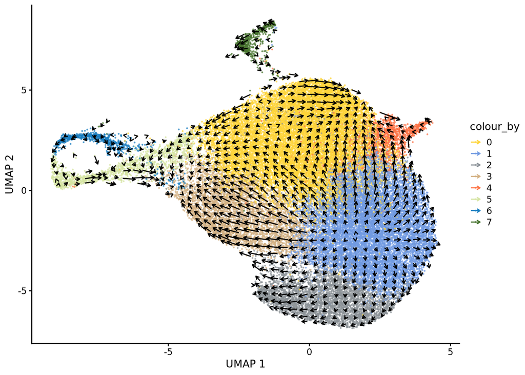

```r
if (subset_data){pt_size=1} else{pt_size=0.2}

plotReducedDim(sce, "UMAP",colour_by=clu_name, point_size=pt_size) +
    geom_segment(data=grid.df, mapping=aes(x=start.umap_1, y=start.umap_2,
        xend=end.umap_1, yend=end.umap_2, colour=NULL), width=1,arrow=arrow(length=unit(0.05, "inches"))) +
  scale_colour_manual(values=clusters)
```

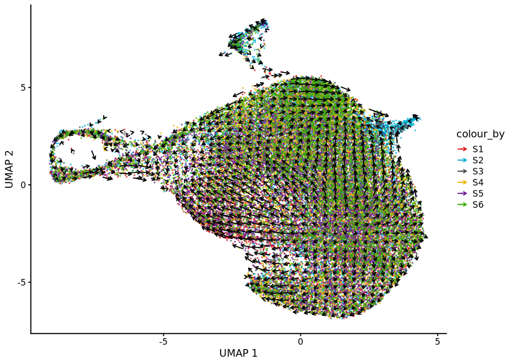

```r
plotReducedDim(sce, "UMAP",colour_by="subject", point_size=pt_size) +
    geom_segment(data=grid.df, mapping=aes(x=start.umap_1, y=start.umap_2,
        xend=end.umap_1, yend=end.umap_2, colour=NULL), width=1,arrow=arrow(length=unit(0.05, "inches"))) +
  scale_colour_manual(values=pal)
```

## Arrows on tSNE

```r
embedded <- embedVelocity(reducedDim(sce, "TSNE"), velo.out)
```

```
## ℹ Using the 'X' assay as the X matrix
```

```
## computing velocity embedding
##     finished (0:00:17) --> added
##     'velocity_target', embedded velocity vectors (adata.obsm)
```

```r
dim(embedded)
```

```
## [1] 42864     2
```

```r
grid.df <- gridVectors(sce, embedded, use.dimred = "TSNE", resolution=40)
head(grid.df)
```

```
##   start.tsne_1 start.tsne_2 end.tsne_1 end.tsne_2
## 1     1.087077     6.410364   1.519504  5.2017748
## 2     8.089592     3.053539   8.797099  1.7521781
## 3    14.042350    13.055838  15.647572 12.0083841
## 4   -17.831280     9.628724 -18.640681  8.8330901
## 5    -3.479114     1.485842  -3.180155  0.7159491
## 6     8.289594     8.286837   9.528912  7.8360989
```

```r
dim(grid.df)
```

```
## [1] 1094    4
```

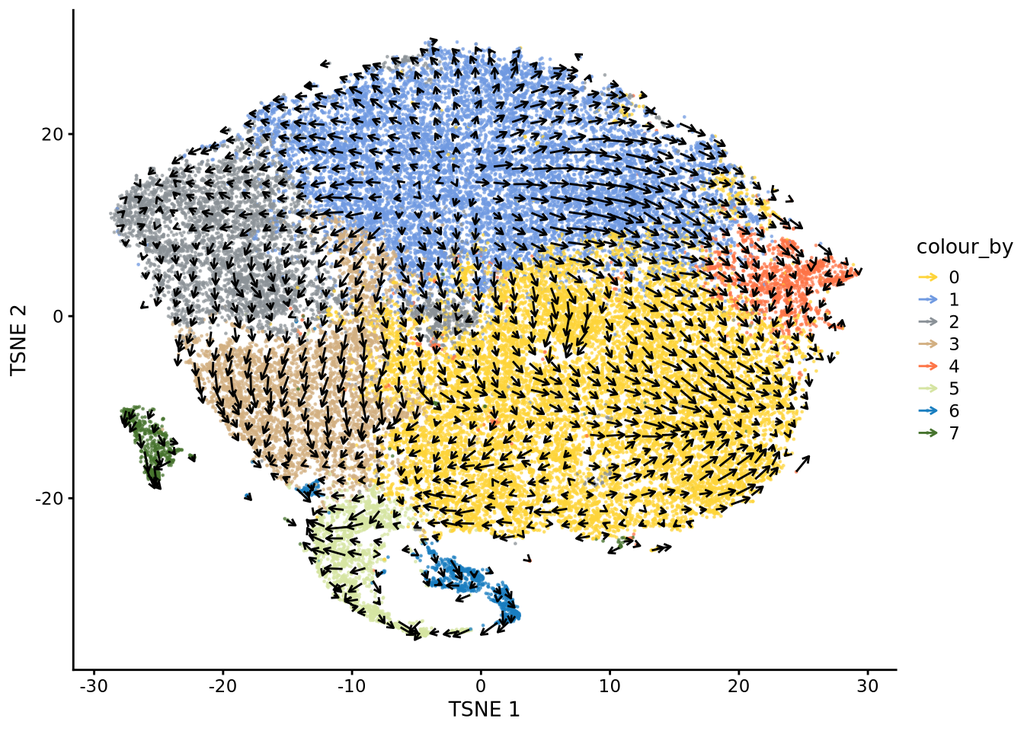

```r
if (subset_data){pt_size=1} else{pt_size=0.2}

plotReducedDim(sce, "TSNE",colour_by=clu_name, point_size=pt_size) +
    geom_segment(data=grid.df, mapping=aes(x=start.tsne_1, y=start.tsne_2,
        xend=end.tsne_1, yend=end.tsne_2, colour=NULL), width=1,arrow=arrow(length=unit(0.05, "inches"))) +
  scale_colour_manual(values=clusters)
```

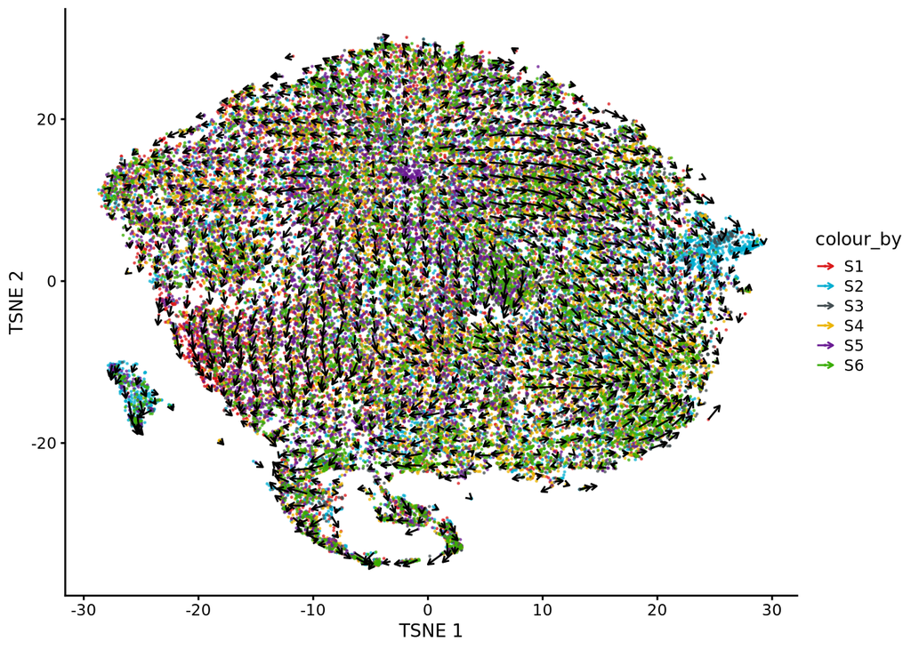

```r
plotReducedDim(sce,"TSNE",colour_by="subject", point_size=pt_size) +
    geom_segment(data=grid.df, mapping=aes(x=start.tsne_1, y=start.tsne_2,
        xend=end.tsne_1, yend=end.tsne_2, colour=NULL), width=1,arrow=arrow(length=unit(0.05, "inches"))) +
  scale_colour_manual(values=pal)
```

## poking around the output object

```r
colnames(colData(velo.out))
```

```
## [1] "velocity_self_transition"       "root_cells"
## [3] "end_points"                     "velocity_pseudotime"
## [5] "latent_time"                    "velocity_length"
## [7] "velocity_confidence"            "velocity_confidence_transition"
```

```r
names(rowData(velo.out))
```

```
##  [1] "fit_r2"                "fit_alpha"             "fit_beta"
##  [4] "fit_gamma"             "fit_t_"                "fit_scaling"
##  [7] "fit_std_u"             "fit_std_s"             "fit_likelihood"
## [10] "fit_u0"                "fit_s0"                "fit_pval_steady"
## [13] "fit_steady_u"          "fit_steady_s"          "fit_variance"
## [16] "fit_alignment_scaling" "velocity_genes"        "varm"
```

I see a column here named root_cells. How does scvelo select root cells?  
velocity confidence, cool, but confidence_transition?

Then we have stuff calculated per gene; like alpha, beta & gamma; fit_steady, fit_likelihood

```r
summary(velo.out$root_cells)
```

```
##    Min. 1st Qu.  Median    Mean 3rd Qu.    Max.
## 0.00000 0.01782 0.04116 0.12579 0.12993 1.00000
```

```r
summary(velo.out$end_points)
```

```
##      Min.   1st Qu.    Median      Mean   3rd Qu.      Max.
## 0.0000000 0.0002012 0.0084453 0.1250088 0.1331068 1.0000000
```

```r
str(metadata(velo.out))
```

```
## List of 5
##  $ neighbors         :List of 4
##   ..$ connectivities_key: chr "connectivities"
##   ..$ distances_key     : chr "distances"
##   ..$ indices           : num [1:42864, 1:30] 0 1 2 3 4 5 6 7 8 9 ...
##   ..$ params            :List of 4
##   .. ..$ n_neighbors: int 30
##   .. ..$ method     : chr "umap"
##   .. ..$ metric     : chr "euclidean"
##   .. ..$ n_pcs      : NULL
##  $ recover_dynamics  :List of 2
##   ..$ fit_connected_states: logi TRUE
##   ..$ use_raw             : logi FALSE
##  $ velocity_params   :List of 5
##   ..$ fit_offset         : logi FALSE
##   ..$ mode               : chr "dynamical"
##   ..$ mode_neighbors     : chr "distances"
##   ..$ n_recurse_neighbors: int 2
##   ..$ perc               : int [1:2] 5 95
##  $ velocity_graph    :Formal class 'dgRMatrix' [package "Matrix"] with 6 slots
##   .. ..@ p       : int [1:42865] 0 441 718 1077 1405 1672 1992 2176 2385 2641 ...
##   .. ..@ j       : int [1:8817037] 390 402 415 516 712 864 891 1057 1444 1595 ...
##   .. ..@ Dim     : int [1:2] 42864 42864
##   .. ..@ Dimnames:List of 2
##   .. .. ..$ : NULL
##   .. .. ..$ : NULL
##   .. ..@ x       : num [1:8817037] 0.0125 0.0569 0.1468 0.0882 0.0471 ...
##   .. ..@ factors : list()
##  $ velocity_graph_neg:Formal class 'dgRMatrix' [package "Matrix"] with 6 slots
##   .. ..@ p       : int [1:42865] 0 100 370 574 705 919 1010 1234 1506 1709 ...
##   .. ..@ j       : int [1:9470301] 501 1012 1744 2287 2781 2997 3012 3499 5279 6273 ...
##   .. ..@ Dim     : int [1:2] 42864 42864
##   .. ..@ Dimnames:List of 2
##   .. .. ..$ : NULL
##   .. .. ..$ : NULL
##   .. ..@ x       : num [1:9470301] -0.06059 -0.03078 -0.00759 -0.06717 -0.03141 ...
##   .. ..@ factors : list()
```

## Velocity confidence and length

confidence = coherence of velocity directions  
length = speed of transcription between cells = roughly arrow length

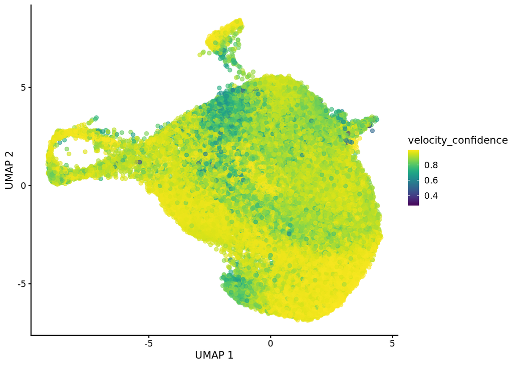

```r
sce$velocity_confidence = velo.out$velocity_confidence
sce$velocity_length = velo.out$velocity_length
plotReducedDim(sce, "UMAP",color_by="velocity_confidence", )
```

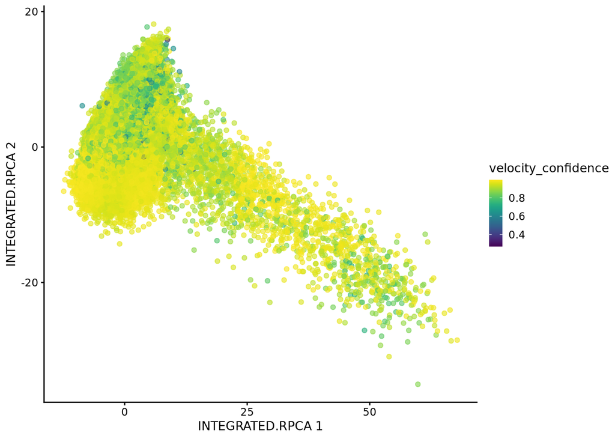

```r
plotReducedDim(sce, red_name,color_by="velocity_confidence", )
```

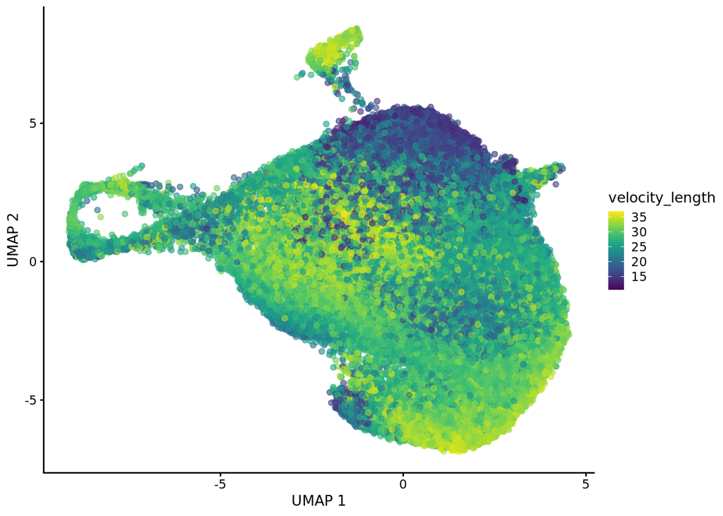

```r
plotReducedDim(sce, "UMAP",color_by="velocity_length" )
```

## Velocity stream plots

```r
colnames(reducedDim(sce, "UMAP"))
```

```
## [1] "umap_1" "umap_2"
```

```r
str(embedded)
```

```
##  num [1:42864, 1:2] 0.538 0.579 0.512 -0.363 0.162 ...
```

```r
colnames(reducedDim(sce, "UMAP")) = c("V1","V2")
str(embedded)
```

```
##  num [1:42864, 1:2] 0.538 0.579 0.512 -0.363 0.162 ...
```

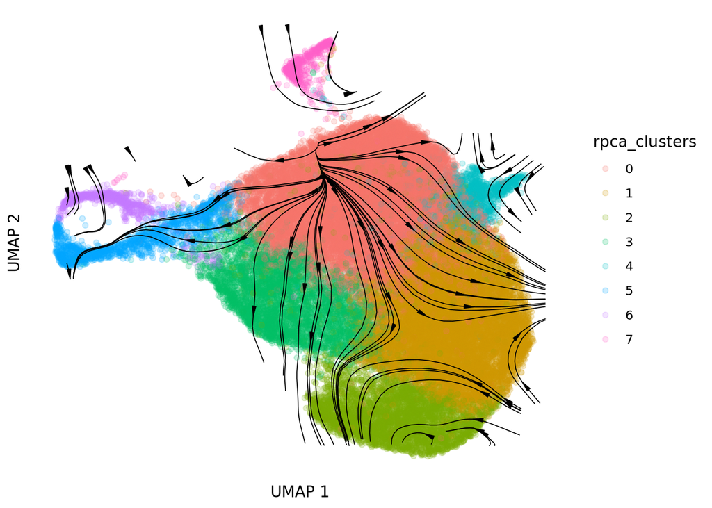

```r
plotVelocityStream(sce, embedded, use.dimred="UMAP",
                   color_by = clu_name,grid.resolution=20,
                   stream.L = 10,
                   arrow.angle = 10, arrow.length = 0.5)
```

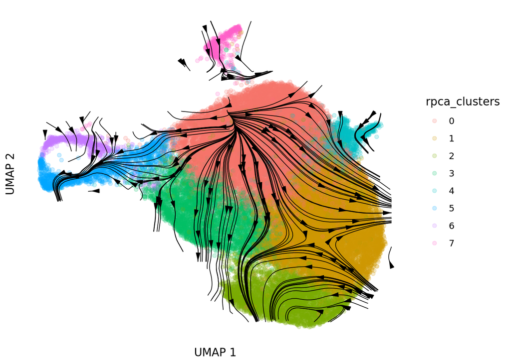

```r
plotVelocityStream(sce, embedded, use.dimred="UMAP",
                   color_by = clu_name,grid.resolution=30,
                   stream.L = 8,
                   arrow.angle = 15, arrow.length = 0.5)
```

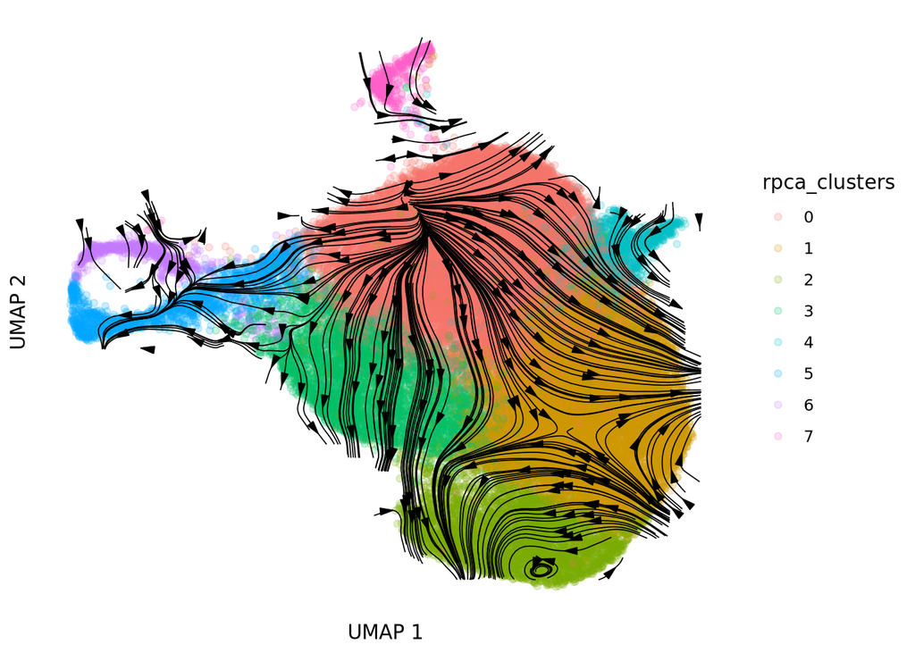

```r
plotVelocityStream(sce, embedded, use.dimred="UMAP",
                   color_by = clu_name,grid.resolution=40,
                   stream.L = 5,
                   arrow.angle = 15, arrow.length = 0.5)
```

```r
if (subset_data == F){
  saveRDS(sce, file = here(odir,paste0(model, "_velocity_scexperiment.rds")))
  saveRDS(velo.out, file = here(odir,paste0(model, "_velocity_output.rds")))

} else if (subset_data){
  saveRDS(sce, file = here(odir,paste0("10%_subset_", model, "_velocity_scexperiment.rds")))
  saveRDS(velo.out, file = here(odir, paste0("10%_subset_", model, "_velocity_output.rds")))
}
```